# Session outline: Pandas

- Introduction to Pandas Series object
- Pandas indexing
- DataFrames
- Getting data into / out of Pandas
- Data Cleansing
- Handling time series data
- Aggregation and grouping
- Merging, joining, and concatenating

# What is Pandas, anyway?

**Pan**el **da**ta

- Uses Numpy for efficient data access & manipulation
- Adds labels and indexes for ease of use
- `Series` and `DataFrame` are the two core classes in Pandas

# Pandas Series

The `pandas.Series` object is like a 1-D array with an index.

```python
import pandas as pd

x = pd.Series([1,2,3,4,5])
x
```

```
0    1
1    2
2    3
3    4
4    5
dtype: int64
```

```python
(x * 5) + x
```

```
0     6
1    12
2    18
3    24
4    30
dtype: int64
```

```python
pd.Series([1,2,3,4,5], dtype=float)
```

```
0    1.0
1    2.0
2    3.0
3    4.0
4    5.0
dtype: float64
```

```python
import numpy as np
```

```python
np.float128
```

```
numpy.float128
```

```python
pd.Series([1,2,'hello'])
```

```
0        1
1        2
2    hello
dtype: object
```

```python
data = pd.Series([1.0, 2, 3, 4, 5])
data
```

```
0    1.0
1    2.0
2    3.0
3    4.0
4    5.0
dtype: float64
```

```python
data[3] = 3.14
data
```

```
0    1.00
1    2.00
2    3.00
3    3.14
4    5.00
dtype: float64
```

```python
data[3] = 15
data
```

```
0     1.0
1     2.0
2     3.0
3    15.0
4     5.0
dtype: float64
```

Pandas uses `numpy.array` objects to store data:

```python
data.values
```

```
array([ 1.,  2.,  3., 15.,  5.])
```

# Pandas indexing

To access values (or slices) and Pandas indexes, we can use either the label-based index, or position:

We can use non-integer indexes:

```python
data = pd.Series([1.0, 2, 3, 4, 5], index=['a', 'b', 'c', 'd', 'e'])
data
```

```
a    1.0
b    2.0
c    3.0
d    4.0
e    5.0
dtype: float64
```

```python
data['a']
```

```
1.0
```

```python
data[0]
```

```
1.0
```

If we use labels to index, Pandas considers slices *inclusive* of both bounds:

```python
data['a':'c']
```

```
a    1.0
b    2.0
c    3.0
dtype: float64
```

Using positions, however, Pandas uses normal Python half-open intervals:

```python
data[0:3]
```

```
a    1.0
b    2.0
c    3.0
dtype: float64
```

Pandas has several different index types:

```python
data.index
```

```
Index(['a', 'b', 'c', 'd', 'e'], dtype='object')
```

```python
pd.Series([0, 1, 2]).index
```

```
RangeIndex(start=0, stop=3, step=1)
```

```python
data = pd.Series(range(100))
data.index
```

```
RangeIndex(start=0, stop=100, step=1)
```

```python
data[::20].index
```

```
RangeIndex(start=0, stop=100, step=20)
```

```python
data[::20][0] = 200
```

```python
data.head()
```

```
0    200
1      1
2      2
3      3
4      4
dtype: int64
```

```python
data.tail()
```

```
95    95
96    96
97    97
98    98
99    99
dtype: int64
```

## Datetime indexing

```python
from datetime import datetime, date
data = pd.Series(range(300), pd.date_range(date.today(), periods=300, freq='1D'))
data.head()
```

```
2019-03-22    0
2019-03-23    1
2019-03-24    2
2019-03-25    3
2019-03-26    4
Freq: D, dtype: int64
```

```python
data.index
```

```
DatetimeIndex(['2019-03-22', '2019-03-23', '2019-03-24', '2019-03-25',
               '2019-03-26', '2019-03-27', '2019-03-28', '2019-03-29',
               '2019-03-30', '2019-03-31',
               ...
               '2020-01-06', '2020-01-07', '2020-01-08', '2020-01-09',
               '2020-01-10', '2020-01-11', '2020-01-12', '2020-01-13',
               '2020-01-14', '2020-01-15'],
              dtype='datetime64[ns]', length=300, freq='D')
```

```python
data[::30].index
```

```
DatetimeIndex(['2019-03-22', '2019-04-21', '2019-05-21', '2019-06-20',
               '2019-07-20', '2019-08-19', '2019-09-18', '2019-10-18',
               '2019-11-17', '2019-12-17'],
              dtype='datetime64[ns]', freq='30D')
```

```python
from datetime import datetime, date
data = pd.Series(range(300), pd.date_range(datetime.now(), periods=300, freq='17s'))
data.head()
```

```
2019-03-22 16:16:37.583774    0
2019-03-22 16:16:54.583774    1
2019-03-22 16:17:11.583774    2
2019-03-22 16:17:28.583774    3
2019-03-22 16:17:45.583774    4
Freq: 17S, dtype: int64
```

We can be particularly perverse when using integer-based indexes:

```python
data = pd.Series(range(5), [1, 3, 4, 2, 0])
data
```

```
1    0
3    1
4    2
2    3
0    4
dtype: int64
```

Label-based indexing with a single value!

```python
data[1]
```

```
0
```

```python
data[0]
```

```
4
```

Location-based indexing with slices!

```python
data[0:3]
```

```
1    0
3    1
4    2
dtype: int64
```

## Using .loc and .iloc

To eliminate confusion, Pandas gives us explicit indexing via `.loc` and `.iloc`

**`.loc`** uses label-based indexing **`.iloc`** uses location-based ("implicit") indexing

```python
data.loc[0]
```

```
4
```

```python
data.iloc[0]
```

```
0
```

```python
data
```

```
1    0
3    1
4    2
2    3
0    4
dtype: int64
```

```python
data.loc[0:3]
```

```
Series([], dtype: int64)
```

```python
data.iloc[0:3]
```

```
1    0
3    1
4    2
dtype: int64
```

```python
data.loc[3:0]
```

```
3    1
4    2
2    3
0    4
dtype: int64
```

# Dict-as-series

```python
population = pd.Series({
    'CA': 38332521,
    'TX': 26448193,
    'NY': 19651127,
    'FL': 19552860,
    'IL': 12882135})
population
```

```
CA    38332521
TX    26448193
NY    19651127
FL    19552860
IL    12882135
dtype: int64
```

```python
population['TX']
```

```
26448193
```

```python
population['NY': 'IL']
```

```
NY    19651127
FL    19552860
IL    12882135
dtype: int64
```

```python
population[1:3]
```

```
TX    26448193
NY    19651127
dtype: int64
```

```python
population.loc['NY': 'IL']
```

```
NY    19651127
FL    19552860
IL    12882135
dtype: int64
```

# Dataframes

Pandas also provides a `DataFrame` object that can be used for 2-D tabular data:

```python
area = pd.Series({
    'CA': 423967,
    'TX': 695662,
    'NY': 141297,
    'FL': 170312,
    'IL': 149995
})
area
```

```
CA    423967
TX    695662
NY    141297
FL    170312
IL    149995
dtype: int64
```

```python
data = pd.DataFrame({'population': population, 'area': area})
data
```

|  | population | area |
| --- | --- | --- |
| CA | 38332521 | 423967 |
| TX | 26448193 | 695662 |
| NY | 19651127 | 141297 |
| FL | 19552860 | 170312 |
| IL | 12882135 | 149995 |

```python
data['area']
```

```
CA    423967
TX    695662
NY    141297
FL    170312
IL    149995
Name: area, dtype: int64
```

```python
data.area
```

```
CA    423967
TX    695662
NY    141297
FL    170312
IL    149995
Name: area, dtype: int64
```

```python
data[['population']]
```

|  | population |
| --- | --- |
| CA | 38332521 |
| TX | 26448193 |
| NY | 19651127 |
| FL | 19552860 |
| IL | 12882135 |

```python
data[['population']].values
```

```
array([[38332521],
       [26448193],
       [19651127],
       [19552860],
       [12882135]])
```

```python
data['population'].values
```

```
array([38332521, 26448193, 19651127, 19552860, 12882135])
```

```python
data['population'].name
```

```
'population'
```

When creating a DataFrame, Pandas conforms the indexes of the Series objects to a shared index, filling in NaN where it can't:

```python
area = pd.Series({
    'CA': 423967,
    'TX': 695662,
    'NY': 141297,
    'FL': 170312,
    'IL': 149995,
    'GA': 153910,
})
area
```

```
CA    423967
TX    695662
NY    141297
FL    170312
IL    149995
GA    153910
dtype: int64
```

```python
population
```

```
CA    38332521
TX    26448193
NY    19651127
FL    19552860
IL    12882135
dtype: int64
```

```python
data = pd.DataFrame({'population': population, 'area': area})
data
```

|  | population | area |
| --- | --- | --- |
| CA | 38332521.0 | 423967 |
| FL | 19552860.0 | 170312 |
| GA | NaN | 153910 |
| IL | 12882135.0 | 149995 |
| NY | 19651127.0 | 141297 |
| TX | 26448193.0 | 695662 |

```python
data.index
```

```
Index(['CA', 'FL', 'GA', 'IL', 'NY', 'TX'], dtype='object')
```

```python
data.columns
```

```
Index(['population', 'area'], dtype='object')
```

# NaN

```python
import numpy as np
```

```python
None == None
```

```
True
```

```python
None is None
```

```
True
```

```python
np.nan is np.nan
```

```
True
```

```python
np.nan == np.nan, np.nan < np.nan, np.nan > np.nan
```

```
(False, False, False)
```

```python
pd.NaT is np.nan
```

```
False
```

```python
type(pd.NaT).mro()
```

```
[pandas._libs.tslibs.nattype.NaTType,
 pandas._libs.tslibs.nattype._NaT,
 datetime.datetime,
 datetime.date,
 object]
```

To get a series back, we can simply access the `DataFrame` like a dict:

```python
data['area']
```

```
CA    423967
FL    170312
GA    153910
IL    149995
NY    141297
TX    695662
Name: area, dtype: int64
```

```python
data.area
```

```
CA    423967
FL    170312
GA    153910
IL    149995
NY    141297
TX    695662
Name: area, dtype: int64
```

We can give a list of columns to get a sub-dataframe:

```python
data[['area', 'area', 'area']]
```

|  | area | area | area |
| --- | --- | --- | --- |
| CA | 423967 | 423967 | 423967 |
| FL | 170312 | 170312 | 170312 |
| GA | 153910 | 153910 | 153910 |
| IL | 149995 | 149995 | 149995 |
| NY | 141297 | 141297 | 141297 |
| TX | 695662 | 695662 | 695662 |

```python
data['population']['GA'] = 10.43e6
```

```python
data
```

|  | population | area |
| --- | --- | --- |
| CA | 38332521.0 | 423967 |
| FL | 19552860.0 | 170312 |
| GA | 10430000.0 | 153910 |
| IL | 12882135.0 | 149995 |
| NY | 19651127.0 | 141297 |
| TX | 26448193.0 | 695662 |

## Indexing a DataFrame

It's clearer to use the `.loc` and `.iloc` indexers when updating DataFrames

```python
data.loc['GA']
```

```
population    10430000.0
area            153910.0
Name: GA, dtype: float64
```

```python
data.loc['GA', 'population']
```

```
10430000.0
```

```python
data.loc['GA', 'population'] = 10.31e6
```

```python
data
```

|  | population | area |
| --- | --- | --- |
| CA | 38332521.0 | 423967 |
| FL | 19552860.0 | 170312 |
| GA | 10310000.0 | 153910 |
| IL | 12882135.0 | 149995 |
| NY | 19651127.0 | 141297 |
| TX | 26448193.0 | 695662 |

```python
data['density'] = data.population / data.area
```

```python
data
```

|  | population | area | density |
| --- | --- | --- | --- |
| CA | 38332521.0 | 423967 | 90.413926 |
| FL | 19552860.0 | 170312 | 114.806121 |
| GA | 10310000.0 | 153910 | 66.987200 |
| IL | 12882135.0 | 149995 | 85.883763 |
| NY | 19651127.0 | 141297 | 139.076746 |
| TX | 26448193.0 | 695662 | 38.018740 |

Multi-dimensional slicing works, too.

```python
data.loc['FL': 'IL', 'area']
```

```
FL    170312
GA    153910
IL    149995
Name: area, dtype: int64
```

# Filtering

```python
data.population > 15e6
```

```
CA     True
FL     True
GA    False
IL    False
NY     True
TX     True
Name: population, dtype: bool
```

```python
data.loc[[True, True, False, False, True, True]]
```

|  | population | area | density |
| --- | --- | --- | --- |
| CA | 38332521.0 | 423967 | 90.413926 |
| FL | 19552860.0 | 170312 | 114.806121 |
| NY | 19651127.0 | 141297 | 139.076746 |
| TX | 26448193.0 | 695662 | 38.018740 |

```python
data.loc[data.population > 15e6]
```

|  | population | area | density |
| --- | --- | --- | --- |
| CA | 38332521.0 | 423967 | 90.413926 |
| FL | 19552860.0 | 170312 | 114.806121 |
| NY | 19651127.0 | 141297 | 139.076746 |
| TX | 26448193.0 | 695662 | 38.018740 |

```python
data.loc['GA', 'population'] = np.nan
```

```python
data
```

|  | population | area | density |
| --- | --- | --- | --- |
| CA | 38332521.0 | 423967 | 90.413926 |
| FL | 19552860.0 | 170312 | 114.806121 |
| GA | NaN | 153910 | 66.987200 |
| IL | 12882135.0 | 149995 | 85.883763 |
| NY | 19651127.0 | 141297 | 139.076746 |
| TX | 26448193.0 | 695662 | 38.018740 |

```python
data.dropna()
```

|  | population | area | density |
| --- | --- | --- | --- |
| CA | 38332521.0 | 423967 | 90.413926 |
| FL | 19552860.0 | 170312 | 114.806121 |
| IL | 12882135.0 | 149995 | 85.883763 |
| NY | 19651127.0 | 141297 | 139.076746 |
| TX | 26448193.0 | 695662 | 38.018740 |

```python
data.loc[data.population.isnull() | (data.population > 30e6)]
```

|  | population | area | density |
| --- | --- | --- | --- |
| CA | 38332521.0 | 423967 | 90.413926 |
| GA | NaN | 153910 | 66.987200 |

```python
data.dropna(axis=1)
```

|  | area | density |
| --- | --- | --- |
| CA | 423967 | 90.413926 |
| FL | 170312 | 114.806121 |
| GA | 153910 | 66.987200 |
| IL | 149995 | 85.883763 |
| NY | 141297 | 139.076746 |
| TX | 695662 | 38.018740 |

# Getting data into / out of Pandas

Pandas comes with some convenient data sources

```python
!pip install pandas_datareader
```

[output not shown]

```python
# I have to do this because Pandas is currently ahead of pandas_datareader:
pd.core.common.is_list_like = pd.api.types.is_list_like

import pandas_datareader.data as web
```

```python
start, end = datetime(2014, 1, 1), datetime(2018, 1, 1)
data = web.DataReader(['F', 'TSLA', 'GOOG', 'IBM', 'AAPL', 'CRM'], 'iex', start, end)
```

```python
type(data)
```

```
pandas.core.frame.DataFrame
```

```python
data.keys()
```

```
MultiIndex(levels=[['open', 'high', 'low', 'close', 'volume'], ['AAPL', 'CRM', 'F', 'GOOG', 'IBM', 'TSLA']],
           codes=[[0, 0, 0, 0, 0, 0, 1, 1, 1, 1, 1, 1, 2, 2, 2, 2, 2, 2, 3, 3, 3, 3, 3, 3, 4, 4, 4, 4, 4, 4], [0, 1, 2, 3, 4, 5, 0, 1, 2, 3, 4, 5, 0, 1, 2, 3, 4, 5, 0, 1, 2, 3, 4, 5, 0, 1, 2, 3, 4, 5]],
           names=['Attributes', 'Symbols'])
```

```python
data.head()
```

| Attributes Symbols date | open AAPL | open CRM | open F | open GOOG | open IBM | open TSLA | high AAPL | high CRM | high F | high GOOG | ... | close F | close GOOG | close IBM | close TSLA | volume AAPL | volume CRM | volume F | volume GOOG | volume IBM | volume TSLA |
| --- | --- | --- | --- | --- | --- | --- | --- | --- | --- | --- | --- | --- | --- | --- | --- | --- | --- | --- | --- | --- | --- |
| 2014-03-24 | 70.7117 | 57.51 | 11.7963 | NaN | 156.2531 | 229.75 | 70.9849 | 57.5500 | 11.8421 | NaN | ... | 11.7277 | NaN | 156.9367 | 220.17 | 88924871.0 | 6299376.0 | 27033551.0 | NaN | 5738492.0 | 11332947.0 |
| 2014-03-25 | 71.1162 | 56.81 | 11.7506 | NaN | 157.3618 | 224.14 | 71.6744 | 58.1013 | 11.7811 | NaN | ... | 11.6820 | NaN | 162.5972 | 220.44 | 70573356.0 | 7589329.0 | 24656682.0 | NaN | 10912699.0 | 7865375.0 |
| 2014-03-26 | 71.7755 | 57.08 | 11.7201 | NaN | 162.5472 | 221.95 | 72.1012 | 57.2100 | 11.7658 | NaN | ... | 11.6211 | NaN | 160.5798 | 212.96 | 74942224.0 | 6485360.0 | 24444055.0 | NaN | 6851772.0 | 6907306.0 |
| 2014-03-27 | 70.9212 | 55.00 | 11.6211 | 568.0 | 159.9879 | 212.37 | 71.1162 | 56.6600 | 11.7201 | 568.00 | ... | 11.6211 | 558.46 | 158.2538 | 207.32 | 55507676.0 | 6206120.0 | 28244793.0 | 13052.0 | 6767653.0 | 9505307.0 |
| 2014-03-28 | 70.6986 | 56.07 | 11.6744 | 561.2 | 158.3455 | 212.80 | 70.7800 | 56.9400 | 11.8725 | 566.43 | ... | 11.7735 | 559.99 | 158.7707 | 212.37 | 50141063.0 | 5109517.0 | 36615051.0 | 41003.0 | 5194443.0 | 9684761.0 |

5 rows × 30 columns

```python
data['TSLA'].head()
```

[output not shown]

[output cut: 12 more lines]

[output not shown]

```python
closing_prices = pd.DataFrame({
    ticker: data[ticker].close
    for ticker in data
})
closing_prices.head()
```

[output not shown]

```python
closing_prices.tail()
```

```python
%matplotlib inline
```

```python
closing_prices.describe()
```

```python
closing_prices.plot()
```

[output not shown]

We can also read CSV data, if we have it:

```python
!head data/closing-prices.csv
```

```
,F,TSLA,GOOG,IBM,AAPL
2014-01-02,12.089,150.1,,157.6001,72.7741
2014-01-03,12.1438,149.56,,158.543,71.1756
2014-01-06,12.1986,147.0,,157.9993,71.5637
2014-01-07,12.042,149.36,,161.1508,71.0516
2014-01-08,12.1673,151.28,,159.6728,71.5019
2014-01-09,12.4022,147.53,,159.1716,70.5887
2014-01-10,12.5822,145.7199,,159.0696,70.1178
2014-01-13,12.6136,139.34,,156.4363,70.4849
2014-01-14,12.8406,161.27,,157.9314,71.8874
```

```python
closing_prices = pd.read_csv('data/closing-prices.csv')
closing_prices.head()
```

|  | Unnamed: 0 | F | TSLA | GOOG | IBM | AAPL |
| --- | --- | --- | --- | --- | --- | --- |
| 0 | 2014-01-02 | 12.0890 | 150.10 | NaN | 157.6001 | 72.7741 |
| 1 | 2014-01-03 | 12.1438 | 149.56 | NaN | 158.5430 | 71.1756 |
| 2 | 2014-01-06 | 12.1986 | 147.00 | NaN | 157.9993 | 71.5637 |
| 3 | 2014-01-07 | 12.0420 | 149.36 | NaN | 161.1508 | 71.0516 |
| 4 | 2014-01-08 | 12.1673 | 151.28 | NaN | 159.6728 | 71.5019 |

We can use various options with read_csv to get better data:

```python
import pandas as pd
closing_prices = pd.read_csv('data/closing-prices.csv', index_col=0, parse_dates=[0])
closing_prices.head()
```

|  | F | TSLA | GOOG | IBM | AAPL |
| --- | --- | --- | --- | --- | --- |
| 2014-01-02 | 12.0890 | 150.10 | NaN | 157.6001 | 72.7741 |
| 2014-01-03 | 12.1438 | 149.56 | NaN | 158.5430 | 71.1756 |
| 2014-01-06 | 12.1986 | 147.00 | NaN | 157.9993 | 71.5637 |
| 2014-01-07 | 12.0420 | 149.36 | NaN | 161.1508 | 71.0516 |
| 2014-01-08 | 12.1673 | 151.28 | NaN | 159.6728 | 71.5019 |

We can use strings to index dates:

```python
%matplotlib inline
```

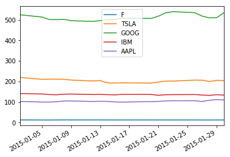

```python
closing_prices['01/02/2015': '2015-02-01'].plot()
```

# Data cleansing with Pandas

We might want to ensure we have all the days in the range:

```python
closing_prices.index.min()
```

```
Timestamp('2014-01-02 00:00:00')
```

```python
closing_prices.index.max()
```

```
Timestamp('2017-12-29 00:00:00')
```

```python
data = pd.DataFrame(index=pd.date_range(
    start=closing_prices.index.min(),
    end=closing_prices.index.max()
))
```

```python
for ticker in closing_prices.columns:
    data[ticker] = closing_prices[ticker]
```

```python
data.head()
```

|  | F | TSLA | GOOG | IBM | AAPL |
| --- | --- | --- | --- | --- | --- |
| 2014-01-02 | 12.0890 | 150.10 | NaN | 157.6001 | 72.7741 |
| 2014-01-03 | 12.1438 | 149.56 | NaN | 158.5430 | 71.1756 |
| 2014-01-04 | NaN | NaN | NaN | NaN | NaN |
| 2014-01-05 | NaN | NaN | NaN | NaN | NaN |
| 2014-01-06 | 12.1986 | 147.00 | NaN | 157.9993 | 71.5637 |

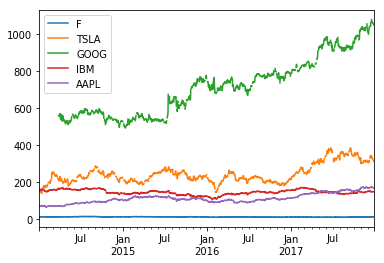

```python
data.plot();
```

# What do we do with NaNs?

For GOOG data, we probably want to leave them

For other data, maybe forward-fill?

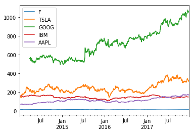

```python
data.fillna(method='ffill').plot()
```

## Cleaning up string data

First, let's make some reasonably dirty data:

```python
import numpy as np
data = pd.read_csv('data/dirty_prices.csv', )
data.head()
```

|  | sku | category | price |
| --- | --- | --- | --- |
| 0 | sku0000 | Toilets | $2,085.11 |
| 1 | sku0001 | Misc | $3,601.62 |
| 2 | sku0002 | Misc | $0.57 |
| 3 | sku0003 | Faucets | $1,511.66 |
| 4 | sku0004 | Toilets | $733.78 |

# Question: what's the median price?

First, a naive approach:

```python
data.price.mean()
```

[output not shown]

[output cut: 53 more lines]

[output not shown]

```python
import re
dollar_comma = re.compile(r'[$,]')

def find_median(series):
    items = []
    for item in series:
        item = dollar_comma.sub('', item)
        item = float(item)
        items.append(item)
    items.sort()
    midpoint = (len(items) - 1) / 2
    if midpoint != int(midpoint):
        return (items[int(np.floor(midpoint))] + items[int(np.ceil(midpoint))]) / 2
    else:
        return items[int(midpoint)]
```

```python
%%timeit
find_median(data.price)
```

```
137 ms ± 2 ms per loop (mean ± std. dev. of 7 runs, 10 loops each)
```

```python
%%timeit
data.price.str.replace(dollar_comma, '').astype(float).median()
```

```
117 ms ± 950 µs per loop (mean ± std. dev. of 7 runs, 10 loops each)
```

Or we can use the power of Pandas:

```python
cleaned = data.price.str.replace(dollar_comma, '')
cleaned.head()
```

```
0    2085.11
1    3601.62
2       0.57
3    1511.66
4     733.78
Name: price, dtype: object
```

```python
cleaned.astype(float).head()
```

```
0    2085.11
1    3601.62
2       0.57
3    1511.66
4     733.78
Name: price, dtype: float64
```

```python
cleaned.astype(float).median()
```

```
2499.49
```

```python
def cleanup(value):
    return float(dollar_comma.sub('', value))
```

```python
data.price.apply(cleanup).median()
```

```
2499.49
```

# Counting things, finding outliers

```python
data.category.value_counts()  # kerning / keming
```

```
Misc        25121
Toilets     25041
Faucets     24967
Showers     24860
M.isc           2
Mi.sc           1
Fauc.ets        1
Show.ers        1
Toile.ts        1
Fa.ucets        1
Faucet.s        1
Showe.rs        1
Fauce.ts        1
Name: category, dtype: int64
```

```python
data.head()
```

|  | sku | category | price |
| --- | --- | --- | --- |
| 0 | sku0000 | Toilets | $2,085.11 |
| 1 | sku0001 | Misc | $3,601.62 |
| 2 | sku0002 | Misc | $0.57 |
| 3 | sku0003 | Faucets | $1,511.66 |
| 4 | sku0004 | Toilets | $733.78 |

```python
data['price'] = data.price.str.replace(dollar_comma, '').astype(float)
```

```python
data.head()
```

|  | sku | category | price |
| --- | --- | --- | --- |
| 0 | sku0000 | Toilets | 2085.11 |
| 1 | sku0001 | Misc | 3601.62 |
| 2 | sku0002 | Misc | 0.57 |
| 3 | sku0003 | Faucets | 1511.66 |
| 4 | sku0004 | Toilets | 733.78 |

```python
data.describe()
```

|  | price |
| --- | --- |
| count | 9.999900e+04 |
| mean | 4.195476e+03 |
| std | 2.327875e+05 |
| min | 5.000000e-02 |
| 25% | 1.235450e+03 |
| 50% | 2.499490e+03 |
| 75% | 3.749220e+03 |
| max | 4.828977e+07 |

```python
data.describe(percentiles=np.r_[0:1:0.01])
```

|  | price |
| --- | --- |
| count | 9.999900e+04 |
| mean | 4.195476e+03 |
| std | 2.327875e+05 |
| min | 5.000000e-02 |
| 0% | 5.000000e-02 |
| 1% | 5.079940e+01 |
| 2% | 9.743880e+01 |
| 3% | 1.476058e+02 |
| 4% | 1.961300e+02 |
| 5% | 2.452120e+02 |
| 6% | 2.941076e+02 |
| 7.0% | 3.442958e+02 |
| 8% | 3.924668e+02 |
| 9% | 4.422482e+02 |
| 10% | 4.922340e+02 |
| 11% | 5.440312e+02 |
| 12% | 5.941836e+02 |
| 13% | 6.453774e+02 |
| 14.0% | 6.925672e+02 |
| 15% | 7.430560e+02 |
| 16% | 7.920104e+02 |
| 17% | 8.439730e+02 |
| 18% | 8.955592e+02 |
| 19% | 9.455148e+02 |
| 20% | 9.938860e+02 |
| 21% | 1.042350e+03 |
| 22% | 1.088810e+03 |
| 23% | 1.138504e+03 |
| 24% | 1.186890e+03 |
| 25% | 1.235450e+03 |
| ... | ... |
| 71% | 3.548087e+03 |
| 72% | 3.601138e+03 |
| 73% | 3.651251e+03 |
| 74% | 3.701790e+03 |
| 75% | 3.749220e+03 |
| 76% | 3.799994e+03 |
| 77% | 3.848830e+03 |
| 78% | 3.901820e+03 |
| 79% | 3.952325e+03 |
| 80% | 3.999800e+03 |
| 81% | 4.048985e+03 |
| 82% | 4.098789e+03 |
| 83% | 4.151914e+03 |
| 84% | 4.204093e+03 |
| 85% | 4.252768e+03 |
| 86% | 4.304726e+03 |
| 87% | 4.356020e+03 |
| 88% | 4.402337e+03 |
| 89% | 4.453652e+03 |
| 90% | 4.503554e+03 |
| 91% | 4.551591e+03 |
| 92% | 4.601601e+03 |
| 93% | 4.652302e+03 |
| 94% | 4.699841e+03 |
| 95% | 4.749155e+03 |
| 96% | 4.799272e+03 |
| 97% | 4.849401e+03 |
| 98% | 4.900740e+03 |
| 99% | 4.948921e+03 |
| max | 4.828977e+07 |

105 rows × 1 columns

```python
data.price.quantile(.999)
```

```
4995.26018
```

```python
data.price.max()
```

```
48289766.08
```

```python
outlier = (data.price - data.price.mean()).abs() > data.price.std() * 2
outlier.sum()
```

```
7
```

```python
data.price[outlier]
```

```
619      20210095.29
9403      9649098.09
19112    36594646.07
20176    48289766.08
23842     6326230.69
71489    26927286.67
94456    21956736.87
Name: price, dtype: float64
```

Let's fill with the mean value

```python
data.loc[outlier, 'price'] = np.nan
```

```python
data.price.fillna(data.price.mean(), inplace=True)
```

```python
data.describe()
```

|  | price |
| --- | --- |
| count | 99999.000000 |
| mean | 2496.094640 |
| std | 1446.777317 |
| min | 0.050000 |
| 25% | 1235.450000 |
| 50% | 2499.130000 |
| 75% | 3748.775000 |
| max | 4999.950000 |

```python
data.head()
```

|  | sku | category | price |
| --- | --- | --- | --- |
| 0 | sku0000 | Toilets | 2085.11 |
| 1 | sku0001 | Misc | 3601.62 |
| 2 | sku0002 | Misc | 0.57 |
| 3 | sku0003 | Faucets | 1511.66 |
| 4 | sku0004 | Toilets | 733.78 |

```python
pd.get_dummies(data, columns=['category'], drop_first=False).head()
```

# Data cleansing exercise

Exercise 6

# Time Series Data

```python
sales = pd.read_csv('sales.csv', parse_dates=['date'])
sales.head()
```

```python
sales.loc[sales.date > '2012-01-01'].head()
```

```python
sales['weekday'] = sales.date.dt.weekday
sales.head()
```

```python
sales['weekend'] = sales.weekday > 4
sales.head()
```

# Merging data

```python
data.head()
```

```python
product = data
```

```python
merged = sales.merge(product, on='sku')
merged.head()
```

```python
iproduct = product.set_index('sku')
```

```python
sales.join(iproduct, on='sku').head()
```

```python
merged.category.value_counts()
```

# Grouping data

```python
merged['extended'] = merged.qty * merged.price
```

```python
merged['month_name'] = merged.date.dt.month_name()
```

```python
merged.groupby('month_name').extended.sum()
```

```python
g = merged.groupby(['category', 'date'])
```

```python
g
```

```python
pd.read_csv()
```

# Crash data

```python
import seaborn as sns
```

```python
crash_data = sns.load_dataset('car_crashes')
```

```python
crash_data.head()
```

```python
crash_data.describe()
```

```python
crash_data.set_index('abbrev', inplace=True)
crash_data.head()
```

```python
crash_data.total.nlargest(5)
```

```python
states = pd.read_csv('states.csv', index_col=0)
states.head()
```

```python
merged_crash = crash_data.merge(states, left_index=True, right_index=True)
merged_crash.head()
```

```python
merged_crash.info()
```

```python
merged_crash.dropna(inplace=True)
```

```python
merged_crash['normalized'] = merged_crash.total / merged_crash['pop']
```

```python
merged_crash.nlargest(5, 'normalized')
```

## Aside on concatenation

We can concatenate data as well using concat:

```python
dat = pd.concat([merged_crash, merged_crash.nlargest(5, 'normalized')])
```

```python
dat.describe()
```

```python
dat.drop_duplicates(inplace=True)
dat.describe()
```

```python
g.agg({'qty': {'mean': np.mean, 'median': np.median}}).head()
```

```python
dat = pd.read_csv('./sales.csv', header=None)
```

```python
dat.head()
```

```python
dat.columns = dat.iloc[0]
dat.head()
```

```python
dat.drop([0], axis=0).head()
```

# Group/merge exercise

Exercise

# Other data integration

```python
!rm data/dirty-prices.db
```

```python
import sqlite3
conn = sqlite3.connect('./data/dirty-prices.db')
dat = pd.read_csv('./data/dirty_prices.csv')
dat.to_sql('dirty_prices', conn)
```

```python
pd.read_sql('select sku, price from dirty_prices', conn, index_col='sku').head()
```

```python
%store product
```

```python
merged.head()
```

```python
now = datetime.now()
```

```python
now >= datetime(2011, 1, 1) and now < datetime(2011, 2, 1)
```

```python
merged[(merged.date >= '2011-01-01') & (merged.date < '2011-02-01')].head()
```

```python
from datetime import timedelta
merged.date.apply(lambda x: x + timedelta(days=2)).head()
```

# Lab

Open the Pandas Lab